# Practical Machine Learning Project: Human Activity Recognition(Weight Lifting Exercise)

Someshwar Rao Sattiraju

September 20, 2017

Script was executed using RStudio on Windows OS

# Background:

Using devices such as Jawbone Up, Nike FuelBand, and Fitbit it is now possible to collect a large amount of data about personal activity relatively inexpensively. These type of devices are part of the quantified self movement – a group of enthusiasts who take measurements about themselves regularly to improve their health, to find patterns in their behavior, or because they are tech geeks. One thing that people regularly do is quantify how much of a particular activity they do, but they rarely quantify how well they do it. In this project, your goal will be to use data from accelerometers on the belt, forearm, arm, and dumbell of 6 participants. They were asked to perform barbell lifts correctly and incorrectly in 5 different ways. More information is available from the website here: http://groupware.les.inf.puc-rio.br/har (see the section on the Weight Lifting Exercise Dataset).

Refrence for the paper: The data for this project come from this source: http://groupware.les.inf.puc-rio.br/har.

# Data

The training data for this project are available here:

https://d396qusza40orc.cloudfront.net/predmachlearn/pml-training.csv

The test data are available here:

https://d396qusza40orc.cloudfront.net/predmachlearn/pml-testing.csv

# About Human Activity Recognition

The human activity recognition research is done to determine different activities being performed( predict which activity was performed at a specific point in time), in this case it was a weight lifting exercise data set.

Read more: http://groupware.les.inf.puc-rio.br/har#ixzz4sQMF9HSB

# Reproducability

Classification and model generation was done using a random number generator seed with value of 1223. In order to reproduce the result the same needs to be used. We will need packages such as RandomForest, caret, rpart, rpartplot for modeling the dataset.

# About How The Model Was Built

Six young health participants were asked to perform one set of 10 repetitions of the Unilateral Dumbbell Biceps Curl in five different fashions: exactly according to the specification (Class A), throwing the elbows to the front (Class B), lifting the dumbbell only halfway (Class C), lowering the dumbbell only halfway (Class D) and throwing the hips to the front (Class E).

Essentially Class A pertains to actual exercise to be performed and rest of the classes - Class B to Class E are wrong ways of doing the exercise or mistakes.

The problem is a classification one and we need to fit a classification model, best model with least error and high accuracy has to be choosen, I chooe 3 methods - Recursive & Generalized Classification Trees, Random Forest and K- Nearest Neighbours to model this dataset.

# Performing Analysis Of The Data Set

Loading Training and Testing data sets and elemenating Null values

```r
library(dplyr)
library(data.table)
set.seed(1223)
#The data set seems to have Missing values, NA, Div/0 error etc., the same needs to be replaced with NA using na.strings
training<-read.csv("S:/Software/R/Data Science Specialization/MACHINE LEARNING/Week4/pml-training.csv",na.strings=c("NA","#DIV/0!",""))
testing<-read.csv("S:/Software/R/Data Science Specialization/MACHINE LEARNING/Week4/pml-testing.csv",na.strings=c("NA","#DIV/0!",""))

dim(training)
```

```
## [1] 19622   160
```

```r
dim(testing)
```

```
## [1]  20 160
```

Plot Of Frequency Of Classe

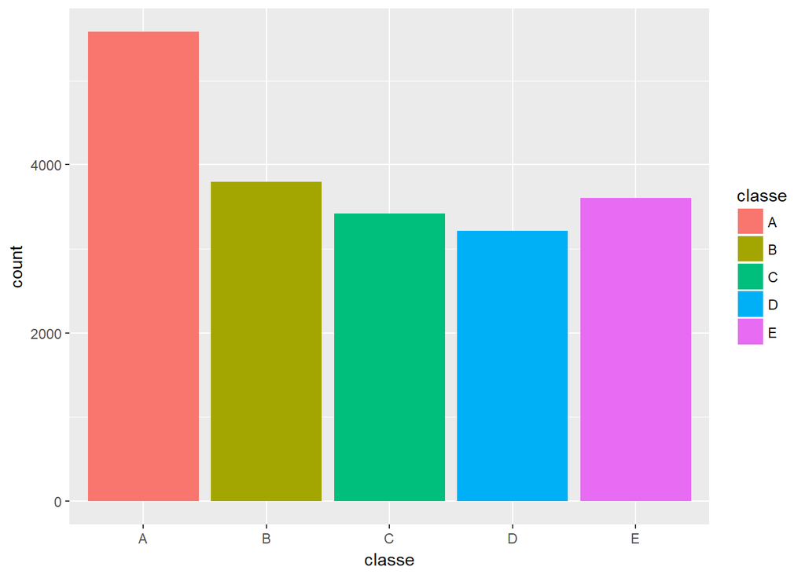

```r
library(ggplot2)
ggplot(data=training,aes(classe))+geom_bar(aes(fill=classe))
```

We subselect the data and devide the same to training and test sets using createDataPartition

This is done by looking at the data and summary of the data ( Attached in Appendix ).

```r
library(caret)
training<- training[ ,colSums(is.na(training)) == 0]
testing<- testing[ ,colSums(is.na(testing)) == 0]

training<-training[,-c(1:7)]
testing<-testing[,-c(1:7)]


dim(training)
```

```
## [1] 19622    53
```

```r
dim(testing)
```

```
## [1] 20 53
```

# Cross Validation And Fitting Classification Tree Using ‘rpart’

Cross validation has been done using createDataPartition funcion to divide the data ( 75% for training and modeling purposes and 25% to testing), multiple models will be fit and the best one which has the most accuracy will be choosen. With the choosen model the test set will be validated.

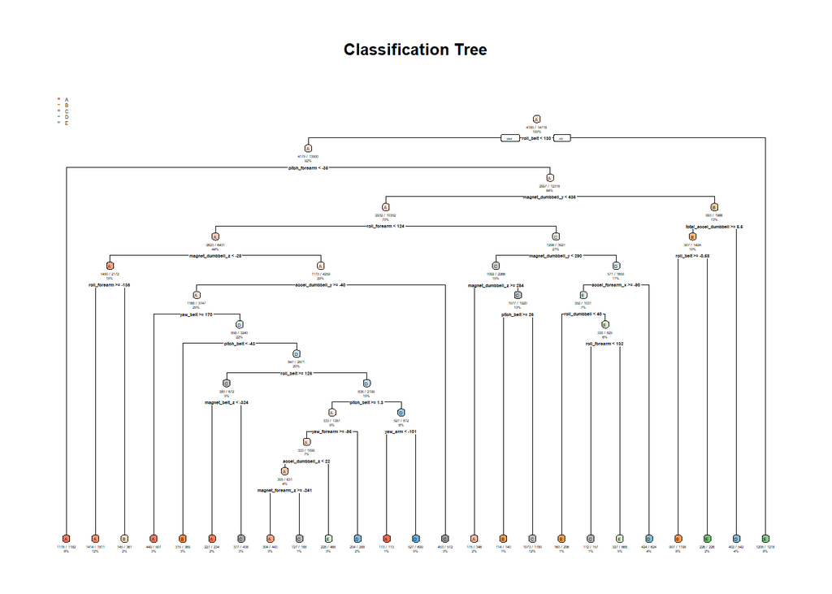

```r
library(rpart)
library(rpart.plot)

inTrain<-createDataPartition(y=training$classe, p=0.75, list=FALSE)
trainset<-training[inTrain,]
testset<-training[-inTrain, ]


mod1<-rpart(classe~., data=trainset, method="class")
prediction1<-predict(mod1, testset, type="class")
rpart.plot(mod1, main="Classification Tree", extra=102, under=TRUE,faclen=0)
```

```r
confusionMatrix(prediction1, testset$classe)
```

```
## Confusion Matrix and Statistics
##
##           Reference
## Prediction    A    B    C    D    E
##          A 1251  145   20   40   20
##          B   60  509   33   58   59
##          C   37  113  732  118   98
##          D   22   76   55  530   52
##          E   25  106   15   58  672
##
## Overall Statistics
##
##                Accuracy : 0.7533
##                  95% CI : (0.7409, 0.7653)
##     No Information Rate : 0.2845
##     P-Value [Acc > NIR] : < 2.2e-16
##
##                   Kappa : 0.6875
##  Mcnemar's Test P-Value : < 2.2e-16
##
## Statistics by Class:
##
##                      Class: A Class: B Class: C Class: D Class: E
## Sensitivity            0.8968   0.5364   0.8561   0.6592   0.7458
## Specificity            0.9359   0.9469   0.9096   0.9500   0.9490
## Pos Pred Value         0.8476   0.7079   0.6667   0.7211   0.7671
## Neg Pred Value         0.9580   0.8949   0.9677   0.9343   0.9431
## Prevalence             0.2845   0.1935   0.1743   0.1639   0.1837
## Detection Rate         0.2551   0.1038   0.1493   0.1081   0.1370
## Detection Prevalence   0.3010   0.1466   0.2239   0.1499   0.1786
## Balanced Accuracy      0.9163   0.7416   0.8829   0.8046   0.8474
```

# Random Forest Model:

```r
library(randomForest)
library(rattle)
mod2 <- randomForest(classe ~. , data= trainset, method="class")
prediction2 <- predict(mod2, testset, type="class")
confusionMatrix(prediction2, testset$classe)
```

```
## Confusion Matrix and Statistics
##
##           Reference
## Prediction    A    B    C    D    E
##          A 1395    3    0    0    0
##          B    0  945    7    0    0
##          C    0    1  848    9    0
##          D    0    0    0  794    5
##          E    0    0    0    1  896
##
## Overall Statistics
##
##                Accuracy : 0.9947
##                  95% CI : (0.9922, 0.9965)
##     No Information Rate : 0.2845
##     P-Value [Acc > NIR] : < 2.2e-16
##
##                   Kappa : 0.9933
##  Mcnemar's Test P-Value : NA
##
## Statistics by Class:
##
##                      Class: A Class: B Class: C Class: D Class: E
## Sensitivity            1.0000   0.9958   0.9918   0.9876   0.9945
## Specificity            0.9991   0.9982   0.9975   0.9988   0.9998
## Pos Pred Value         0.9979   0.9926   0.9883   0.9937   0.9989
## Neg Pred Value         1.0000   0.9990   0.9983   0.9976   0.9988
## Prevalence             0.2845   0.1935   0.1743   0.1639   0.1837
## Detection Rate         0.2845   0.1927   0.1729   0.1619   0.1827
## Detection Prevalence   0.2851   0.1941   0.1750   0.1629   0.1829
## Balanced Accuracy      0.9996   0.9970   0.9947   0.9932   0.9971
```

# K-Nearest Neighbours Model:

```r
mod3 <- train(classe ~., data= trainset, method="knn")
prediction3 <- predict(mod3, testset)
confusionMatrix(prediction3, testset$classe)
```

```
## Confusion Matrix and Statistics
##
##           Reference
## Prediction    A    B    C    D    E
##          A 1336   49   10   17   12
##          B   14  831   22    7   30
##          C   19   25  791   45   20
##          D   23   22   22  722   32
##          E    3   22   10   13  807
##
## Overall Statistics
##
##                Accuracy : 0.915
##                  95% CI : (0.9068, 0.9226)
##     No Information Rate : 0.2845
##     P-Value [Acc > NIR] : < 2.2e-16
##
##                   Kappa : 0.8924
##  Mcnemar's Test P-Value : 1.351e-08
##
## Statistics by Class:
##
##                      Class: A Class: B Class: C Class: D Class: E
## Sensitivity            0.9577   0.8757   0.9251   0.8980   0.8957
## Specificity            0.9749   0.9815   0.9731   0.9759   0.9880
## Pos Pred Value         0.9382   0.9192   0.8789   0.8794   0.9439
## Neg Pred Value         0.9830   0.9705   0.9840   0.9799   0.9768
## Prevalence             0.2845   0.1935   0.1743   0.1639   0.1837
## Detection Rate         0.2724   0.1695   0.1613   0.1472   0.1646
## Detection Prevalence   0.2904   0.1843   0.1835   0.1674   0.1743
## Balanced Accuracy      0.9663   0.9286   0.9491   0.9369   0.9418
```

# Test Data Set & Generation OF File

```r
predictionfinal<-predict(mod2, testing, type="class")
write.csv(predictionfinal,file = "S:/Software/R/Data Science Specialization/MACHINE LEARNING/Week4/TestData.csv",row.names=FALSE)
```

# Appendix

```r
trn<-read.csv("S:/Software/R/Data Science Specialization/MACHINE LEARNING/Week4/pml-training.csv",na.strings=c("NA","#DIV/0!",""))
summary(trn)
```

[output not shown]

[output cut: 313 more lines]

[output not shown]

# Citation

1. http://groupware.les.inf.puc-rio.br/har
2. Velloso, E.; Bulling, A.; Gellersen, H.; Ugulino, W.; Fuks, H. Qualitative Activity Recognition of Weight Lifting Exercises. Proceedings of 4th International Conference in Cooperation with SIGCHI (Augmented Human ’13) . Stuttgart, Germany: ACM SIGCHI, 2013.